# Problem Statement

User data for past one year on various parameters are provided. We need to identify whether the user will make a purchase or not. So we need to make a model that will be able to predict, based on the features identified, whether the user will make a purchase or not. Also we need to identify the features that most significantly affect the use choice and highlight those.

## different column meaning

session_id: unique value -> will not be required

administrative: administrative page type visited by the user (0 means did not visit during that session)

administrative_duration: duration in seconds per visit for administrative page

informational : type of page (0 means did not visit)

infortmational_duration : time spent in informational page

productrelated: page ID visited for different product (this can be useful by taking value count and then seeing which pages people are visiting more often)

productrelated_duration: time spent in each product type page (This will be useful by combining total time spent or taking average time spent per different product page )

bounce_rate: percentage of visitors who enter the site from that page and then leave ("bounce") without triggering any other requests. that may indicate which product people are least interested in i.e. they did not do anything else after visiting that page

exit_rate: as per all page views to the page, the percentage that were the last in the session.

page_value: average value for a web page that a user visited before completing an e-commerce transaction

special_day: indicates closeness of the site visiting time to a specific special day in which the sessions are more likely to be finalized

```python
import warnings
warnings.filterwarnings("ignore")
#imports
import pandas as pd
import numpy as np

#libraries for data visualization
from matplotlib import pyplot as plt
import seaborn as sns

#Libraries for data preprocessing
from sklearn.preprocessing import LabelEncoder
from sklearn.preprocessing import StandardScaler

#libraries for model development
from sklearn.model_selection import train_test_split,GridSearchCV
from sklearn.linear_model import LinearRegression,LogisticRegression,LogisticRegressionCV
from sklearn.tree import DecisionTreeClassifier
from sklearn.svm import SVC
#libaries for evaluation
from sklearn import metrics
```

```python
#!wget https://raw.githubusercontent.com/saumya221/image_viewer_pyqt5/main/ecommerce_train.csv
```

# Load the dataset

```python
data=pd.read_csv("ecommerce_train.csv")
```

```python
# print the shape of the data
print(data.shape)
```

```
(40000, 19)
```

```python
#print the numerical information on the dataset
print(data.describe())
```

```
          session_id  administrative  administrative_duration  informational  \
count   40000.000000    40000.000000             40000.000000   40000.000000
mean   311469.372075        2.544150                89.794383       0.555225
std    108498.432497        3.667252               182.964645       1.332627
min    123460.000000        0.000000                 0.000000       0.000000
25%    217950.000000        0.000000                 0.000000       0.000000
50%    311194.500000        1.000000                11.200000       0.000000
75%    404680.500000        4.000000               110.154167       0.000000
max    499982.000000       22.000000              1946.000000      11.000000

       informational_duration  productrelated  productrelated_duration  \
count            40000.000000    40000.000000             40000.000000
mean                40.977236       34.026975              1148.105672
std                153.114387       46.798102              1666.181462
min                  0.000000        0.000000                 0.000000
25%                  0.000000        7.000000               183.883333
50%                  0.000000       19.000000               560.075000
75%                  0.000000       41.000000              1420.536667
max               1767.666667      440.000000             18504.126210

        bouncerates     exitrates    pagevalues    specialday        region  \
count  40000.000000  40000.000000  40000.000000  40000.000000  40000.000000
mean       0.021969      0.042307      6.494963      0.063553      3.241975
std        0.048533      0.048633     17.710646      0.199463      2.423586
min        0.000000      0.000000      0.000000      0.000000      1.000000
25%        0.000000      0.013389      0.000000      0.000000      1.000000
50%        0.003304      0.025000      0.000000      0.000000      3.000000
75%        0.016667      0.050000      0.000000      0.000000      4.000000
max        0.200000      0.200000    226.677702      1.000000      9.000000

            revenue
count  40000.000000
mean       0.158275
std        0.365003
min        0.000000
25%        0.000000
50%        0.000000
75%        0.000000
max        1.000000
```

```python
data.columns
```

```
Index(['session_id', 'administrative', 'administrative_duration',
       'informational', 'informational_duration', 'productrelated',
       'productrelated_duration', 'bouncerates', 'exitrates', 'pagevalues',
       'specialday', 'month', 'operatingsystems', 'browser', 'region',
       'traffictype', 'visitortype', 'weekend', 'revenue'],
      dtype='object')
```

```python
data.isnull().sum()
```

```
session_id                 0
administrative             0
administrative_duration    0
informational              0
informational_duration     0
productrelated             0
productrelated_duration    0
bouncerates                0
exitrates                  0
pagevalues                 0
specialday                 0
month                      0
operatingsystems           0
browser                    0
region                     0
traffictype                0
visitortype                0
weekend                    0
revenue                    0
dtype: int64
```

```python
#print info and type of the dataset and also the non-null count
print(data.info())
```

```
<class 'pandas.core.frame.DataFrame'>
RangeIndex: 40000 entries, 0 to 39999
Data columns (total 19 columns):
 #   Column                   Non-Null Count  Dtype
---  ------                   --------------  -----
 0   session_id               40000 non-null  int64
 1   administrative           40000 non-null  int64
 2   administrative_duration  40000 non-null  float64
 3   informational            40000 non-null  int64
 4   informational_duration   40000 non-null  float64
 5   productrelated           40000 non-null  int64
 6   productrelated_duration  40000 non-null  float64
 7   bouncerates              40000 non-null  float64
 8   exitrates                40000 non-null  float64
 9   pagevalues               40000 non-null  float64
 10  specialday               40000 non-null  float64
 11  month                    40000 non-null  object
 12  operatingsystems         40000 non-null  object
 13  browser                  40000 non-null  object
 14  region                   40000 non-null  int64
 15  traffictype              40000 non-null  object
 16  visitortype              40000 non-null  object
 17  weekend                  40000 non-null  bool
 18  revenue                  40000 non-null  int64
dtypes: bool(1), float64(7), int64(6), object(5)
memory usage: 5.5+ MB
None
```

So as can be seen , we have no missing data. We have total 40000 rows of data and non-null count for all the features is 40000

```python
# session id can be dropped as it is a unique identifier and has no correlation with the dataset
data.drop('session_id',axis=1,inplace=True)
```

```python
data.info()
```

```
<class 'pandas.core.frame.DataFrame'>
RangeIndex: 40000 entries, 0 to 39999
Data columns (total 18 columns):
 #   Column                   Non-Null Count  Dtype
---  ------                   --------------  -----
 0   administrative           40000 non-null  int64
 1   administrative_duration  40000 non-null  float64
 2   informational            40000 non-null  int64
 3   informational_duration   40000 non-null  float64
 4   productrelated           40000 non-null  int64
 5   productrelated_duration  40000 non-null  float64
 6   bouncerates              40000 non-null  float64
 7   exitrates                40000 non-null  float64
 8   pagevalues               40000 non-null  float64
 9   specialday               40000 non-null  float64
 10  month                    40000 non-null  object
 11  operatingsystems         40000 non-null  object
 12  browser                  40000 non-null  object
 13  region                   40000 non-null  int64
 14  traffictype              40000 non-null  object
 15  visitortype              40000 non-null  object
 16  weekend                  40000 non-null  bool
 17  revenue                  40000 non-null  int64
dtypes: bool(1), float64(7), int64(5), object(5)
memory usage: 5.2+ MB
```

## drop the data that has 0 page view across all three different types of pages i.e. administrative, informational and productrelated

```python
# data.drop(data[(data['informational']==0) & (data['administrative']==0) & (data['productrelated']==0)].index,inplace=True)
# data[(data['informational']==0) & (data['informational_duration']>0)]['informational']
data.loc[(data['informational']==0) & (data['informational_duration']>0),'informational']=np.nan

data.loc[(data['administrative']==0) & (data['administrative_duration']>0),'administrative']=np.nan

data.loc[(data['productrelated']==0) & (data['productrelated_duration']>0),'productrelated']=np.nan
```

```python
# data.drop(data[(data['informational']==0) & (data['informational_duration']>0)].index,inplace=True)
# data[(data['informational']==0) & (data['informational_duration']>0)]['informational'].replace(0,'NaN',inplace=True)
# data[(data['informational']==0) & (data['informational_duration']>0)]['informational']
```

```python
# data.drop(data[(data['productrelated']==0) & (data['productrelated_duration']>0)].index,inplace=True)
```

```python
# data.drop(data[(data['administrative']==0) & (data['administrative_duration']>0)].index,inplace=True)
```

```python
data.info()
data.isna().sum()
```

```
<class 'pandas.core.frame.DataFrame'>
RangeIndex: 40000 entries, 0 to 39999
Data columns (total 18 columns):
 #   Column                   Non-Null Count  Dtype
---  ------                   --------------  -----
 0   administrative           39971 non-null  float64
 1   administrative_duration  40000 non-null  float64
 2   informational            39970 non-null  float64
 3   informational_duration   40000 non-null  float64
 4   productrelated           39926 non-null  float64
 5   productrelated_duration  40000 non-null  float64
 6   bouncerates              40000 non-null  float64
 7   exitrates                40000 non-null  float64
 8   pagevalues               40000 non-null  float64
 9   specialday               40000 non-null  float64
 10  month                    40000 non-null  object
 11  operatingsystems         40000 non-null  object
 12  browser                  40000 non-null  object
 13  region                   40000 non-null  int64
 14  traffictype              40000 non-null  object
 15  visitortype              40000 non-null  object
 16  weekend                  40000 non-null  bool
 17  revenue                  40000 non-null  int64
dtypes: bool(1), float64(10), int64(2), object(5)
memory usage: 5.2+ MB
```

```
administrative             29
administrative_duration     0
informational              30
informational_duration      0
productrelated             74
productrelated_duration     0
bouncerates                 0
exitrates                   0
pagevalues                  0
specialday                  0
month                       0
operatingsystems            0
browser                     0
region                      0
traffictype                 0
visitortype                 0
weekend                     0
revenue                     0
dtype: int64
```

## columns that need data type conversion

1) month 2) operating systems 3) browser 4) traffic type 5) visitor type 6) weekend

```python
data['month'].unique()
```

```
array(['Nov', 'Dec', 'May', 'June', 'Mar', 'Sep', 'Aug', 'Oct', 'Jul',
       'Feb'], dtype=object)
```

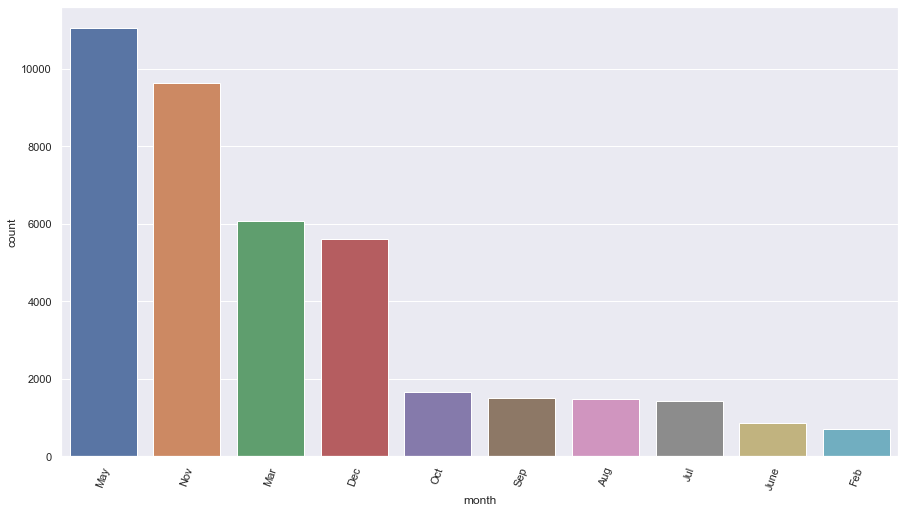

```python
chart = sns.countplot(data['month'], order = data['month'].value_counts().index)
chart.set_xticklabels(chart.get_xticklabels(),rotation=70)
plt.figure(figsize=(10,5))
```

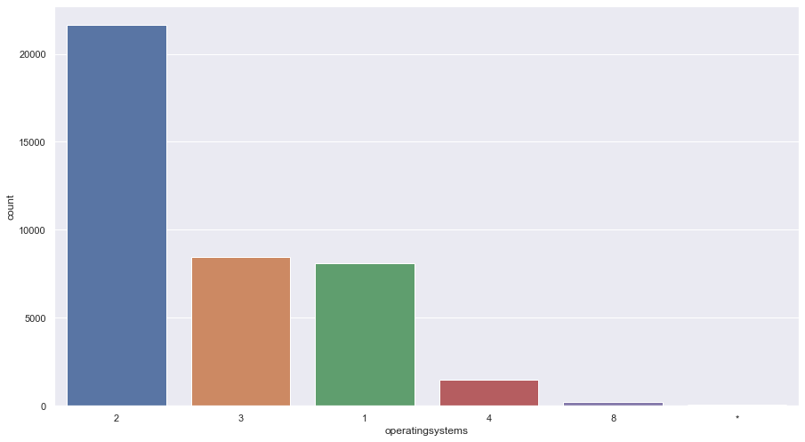

```python
chart = sns.countplot(data['operatingsystems'], order = data['operatingsystems'].value_counts().index)
chart.set_xticklabels(chart.get_xticklabels())
plt.figure(figsize=(10,5))
```

```python
data['operatingsystems'].value_counts()
```

```
2    21638
3     8439
1     8104
4     1498
8      236
*       85
Name: operatingsystems, dtype: int64
```

## as operating systems marked with * are very low in percentage, we will club all of them together in single index of 0

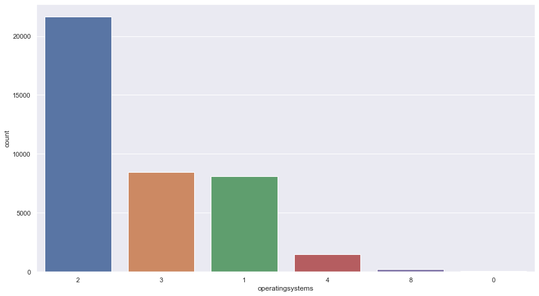

```python
data['operatingsystems']=data['operatingsystems'].replace('*','0')
chart = sns.countplot(data['operatingsystems'], order = data['operatingsystems'].value_counts().index)
chart.set_xticklabels(chart.get_xticklabels())
plt.figure(figsize=(10,5))
#data['operatingsystems']=data['operatingsystems'].astype('int'). # smohanty_temp: will try with pandas get_dummies and see
```

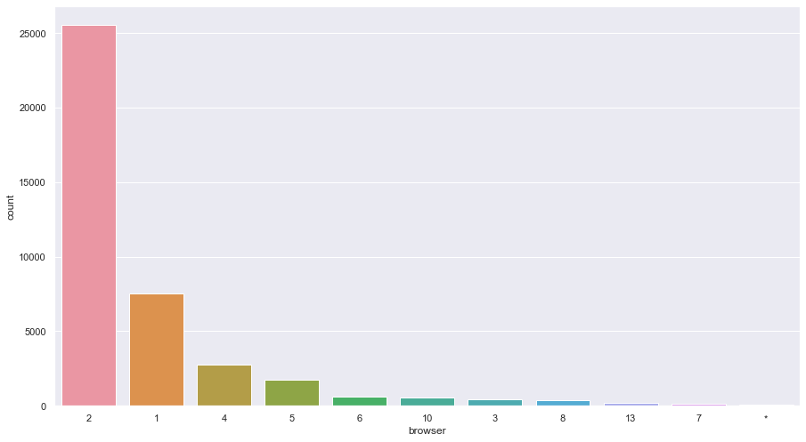

```python
chart = sns.countplot(data['browser'], order = data['browser'].value_counts().index)
chart.set_xticklabels(chart.get_xticklabels())
plt.figure(figsize=(10,5))
```

## as browsers marked with * are very low in percentage, we will club all of them together in single index of 0

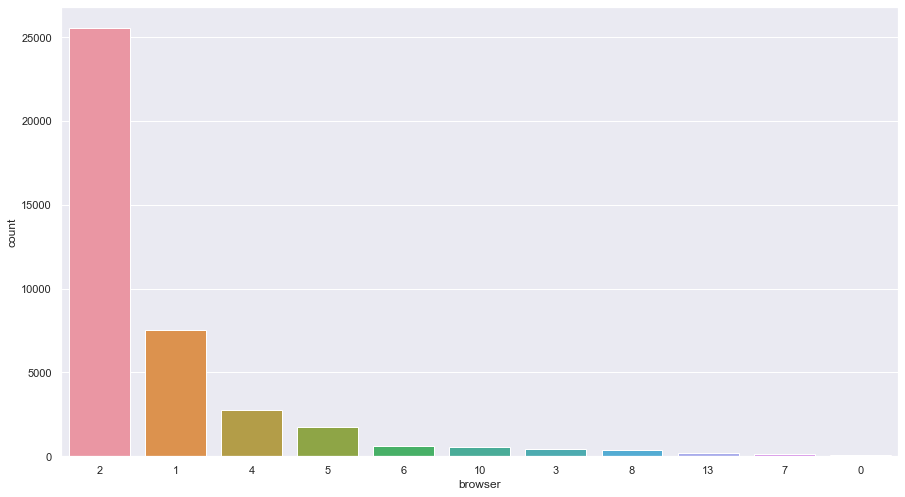

```python
data['browser']=data['browser'].replace('*','0')
chart = sns.countplot(data['browser'], order = data['browser'].value_counts().index)
chart.set_xticklabels(chart.get_xticklabels())
plt.figure(figsize=(10,5))
#data['browser']=data['browser'].astype('int'). # smohanty_temp
```

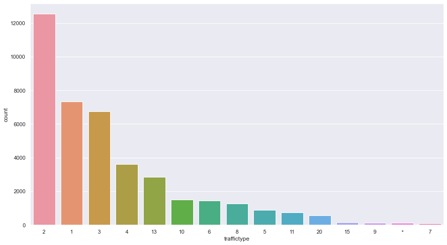

```python
chart = sns.countplot(data['traffictype'], order = data['traffictype'].value_counts().index)
chart.set_xticklabels(chart.get_xticklabels())
plt.figure(figsize=(10,5))
```

## as traffic type marked with * are very low in percentage, we will club all of them together in single index of 0

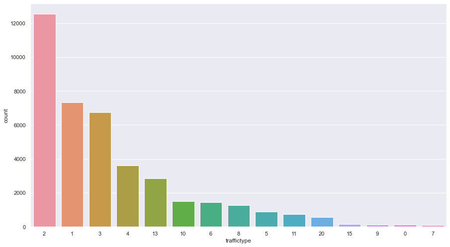

```python
data['traffictype']=data['traffictype'].replace('*','0')
chart = sns.countplot(data['traffictype'], order = data['traffictype'].value_counts().index)
chart.set_xticklabels(chart.get_xticklabels())
plt.figure(figsize=(10,5))
#data['traffictype']=data['traffictype'].astype('int') # smohanty_temp
```

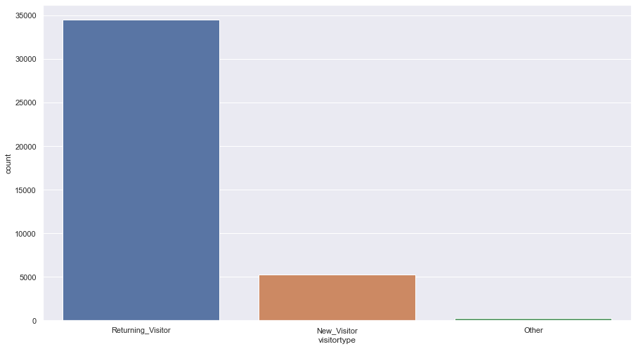

```python
chart = sns.countplot(data['visitortype'], order = data['visitortype'].value_counts().index)
chart.set_xticklabels(chart.get_xticklabels())
plt.figure(figsize=(10,5))
```

```python
# convert bool type for weekend to int
data['weekend']=data['weekend'].astype('int')
```

### As can be seen from above plot, returning visitors are of much higher count as compared to new visitors and other visitors

# EDA

### Correlation between different features

```python
data.corr()
```

|  | administrative | administrative_duration | informational | informational_duration | productrelated | productrelated_duration | bouncerates | exitrates | pagevalues | specialday | region | weekend | revenue |
| --- | --- | --- | --- | --- | --- | --- | --- | --- | --- | --- | --- | --- | --- |
| administrative | 1.000000 | 0.584591 | 0.391376 | 0.274033 | 0.448923 | 0.404122 | -0.216715 | -0.305196 | 0.111947 | -0.113749 | 0.000464 | 0.013802 | 0.153184 |
| administrative_duration | 0.584591 | 1.000000 | 0.280706 | 0.199530 | 0.295017 | 0.295905 | -0.151642 | -0.211213 | 0.078031 | -0.085400 | 0.000327 | 0.017291 | 0.108333 |
| informational | 0.391376 | 0.280706 | 1.000000 | 0.582061 | 0.377951 | 0.382982 | -0.114343 | -0.164425 | 0.081288 | -0.064004 | -0.023256 | 0.017282 | 0.111862 |
| informational_duration | 0.274033 | 0.199530 | 0.582061 | 1.000000 | 0.271146 | 0.281936 | -0.075931 | -0.108674 | 0.058064 | -0.036898 | -0.012577 | 0.015120 | 0.081428 |
| productrelated | 0.448923 | 0.295017 | 0.377951 | 0.271146 | 1.000000 | 0.750811 | -0.203085 | -0.294395 | 0.078932 | -0.047917 | -0.012495 | -0.012419 | 0.183891 |
| productrelated_duration | 0.404122 | 0.295905 | 0.382982 | 0.281936 | 0.750811 | 1.000000 | -0.200532 | -0.282332 | 0.086422 | -0.048580 | -0.016108 | -0.008661 | 0.180542 |
| bouncerates | -0.216715 | -0.151642 | -0.114343 | -0.075931 | -0.203085 | -0.200532 | 1.000000 | 0.893595 | -0.128633 | 0.066774 | -0.011816 | -0.048048 | -0.145773 |
| exitrates | -0.305196 | -0.211213 | -0.164425 | -0.108674 | -0.294395 | -0.282332 | 0.893595 | 1.000000 | -0.171443 | 0.089374 | -0.010686 | -0.058484 | -0.193799 |
| pagevalues | 0.111947 | 0.078031 | 0.081288 | 0.058064 | 0.078932 | 0.086422 | -0.128633 | -0.171443 | 1.000000 | -0.058967 | -0.004583 | 0.009022 | 0.507821 |
| specialday | -0.113749 | -0.085400 | -0.064004 | -0.036898 | -0.047917 | -0.048580 | 0.066774 | 0.089374 | -0.058967 | 1.000000 | -0.013882 | -0.049480 | -0.078758 |
| region | 0.000464 | 0.000327 | -0.023256 | -0.012577 | -0.012495 | -0.016108 | -0.011816 | -0.010686 | -0.004583 | -0.013882 | 1.000000 | -0.005222 | -0.010116 |
| weekend | 0.013802 | 0.017291 | 0.017282 | 0.015120 | -0.012419 | -0.008661 | -0.048048 | -0.058484 | 0.009022 | -0.049480 | -0.005222 | 1.000000 | 0.020203 |
| revenue | 0.153184 | 0.108333 | 0.111862 | 0.081428 | 0.183891 | 0.180542 | -0.145773 | -0.193799 | 0.507821 | -0.078758 | -0.010116 | 0.020203 | 1.000000 |

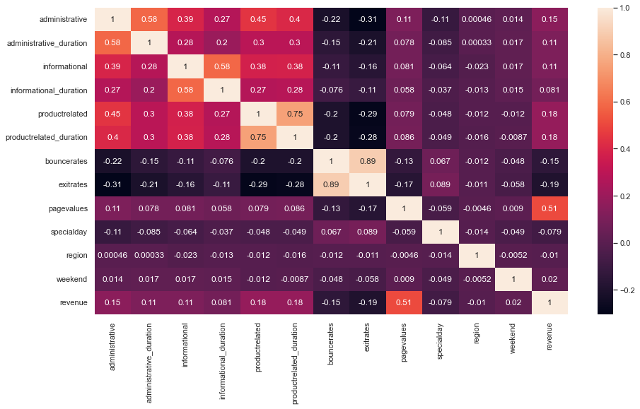

```python
plt.figure(figsize =(15,8))

#Plot the correlation using heatmap
ax = sns.heatmap(data.corr(), annot=True)
```

### Exit rate and bounce rate have strong correlation. So either of the two features can be dropped during model creation.

```python
a=data.corr()
b=a['revenue'].abs()  # take the absolute value
b.sort_values(ascending=False)
```

```
revenue                    1.000000
pagevalues                 0.507821
exitrates                  0.193799
productrelated             0.183891
productrelated_duration    0.180542
administrative             0.153184
bouncerates                0.145773
informational              0.111862
administrative_duration    0.108333
informational_duration     0.081428
specialday                 0.078758
weekend                    0.020203
region                     0.010116
Name: revenue, dtype: float64
```

### [Infenrence] : features (traffictype,weekend,browser,operatingsystems and region) have very less correlation with the target feature "revenue".

```python
#sns.pairplot(data.loc[:,['administrative_duration','informational_duration','productrelated_duration','revenue']],hue='revenue',kind='reg')
```

```
       New_Visitor  Returning_Visitor
month
Aug       0.161334           0.838666
Dec       0.183700           0.816300
Feb       0.050287           0.949713
Jul       0.134548           0.865452
June      0.105140           0.894860
Mar       0.121999           0.878001
May       0.095880           0.904120
Nov       0.124410           0.875590
Oct       0.211957           0.788043
Sep       0.219920           0.780080
```

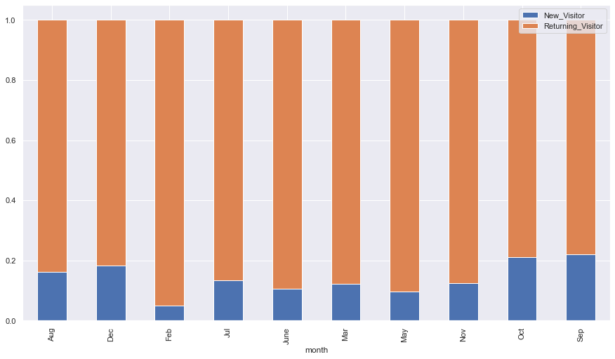

```python
visitor_types=data.groupby('visitortype')['month'].value_counts()
df=pd.DataFrame()
df['New_Visitor']=visitor_types['New_Visitor']/(visitor_types['New_Visitor']+visitor_types['Returning_Visitor'])
df['Returning_Visitor']=visitor_types['Returning_Visitor']/(visitor_types['New_Visitor']+visitor_types['Returning_Visitor'])
print(df)
df.plot.bar(stacked=True)
```

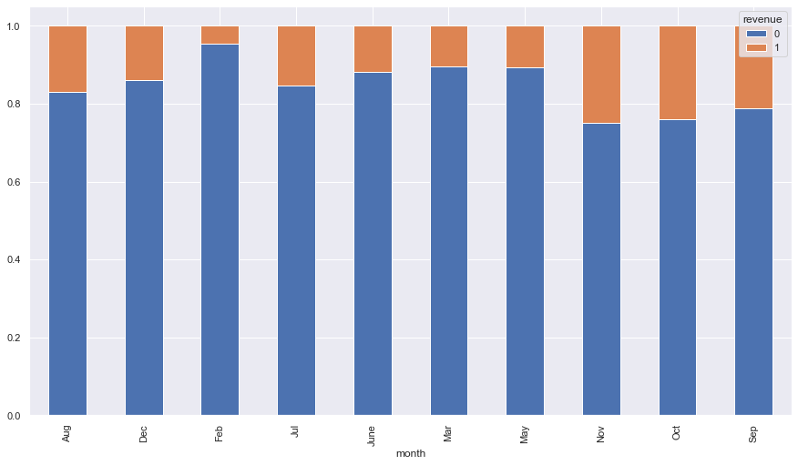

```python
monthwise_revenue=pd.crosstab(data['month'],data['revenue'])
monthwise_revenue_temp=monthwise_revenue.copy()
monthwise_revenue[0]=monthwise_revenue_temp[0]/(monthwise_revenue_temp[0]+monthwise_revenue_temp[1])
monthwise_revenue[1]=monthwise_revenue_temp[1]/(monthwise_revenue_temp[0]+monthwise_revenue_temp[1])
monthwise_revenue.plot.bar(stacked=True)
```

### from the above two plots, it is seen that in the month of February, there is highest percentage of returning visitors out of total visitors, but revenue generation is very low. So some special scheme or offer can be provided during these period to entice customers for purchasing.

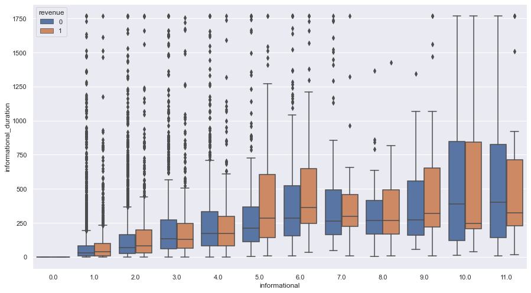

```python
sns.boxplot(x=data['informational'],y=data['informational_duration'],hue=data['revenue'])
```

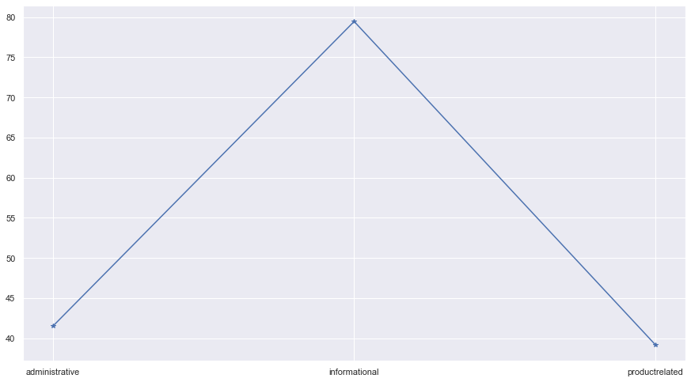

```python
#average time spent by users in different types of pages
admin_time_average=np.mean((data['administrative_duration']/data['administrative']).dropna())
information_time_average=np.mean((data['informational_duration']/data['informational']).dropna())
product_time_average=np.mean((data['productrelated_duration']/data['productrelated']).dropna())
plt.plot(['administrative','informational','productrelated'],[admin_time_average,information_time_average,product_time_average],'-*')
plt.show()
```

### as total time spent in productrelated page is the highest but time spent per productrelated page is almost half of time spent in informational page, design of product page should be clutter free and enticing for the user to make a purchase. More information can be provided in informational pages, as user tend to spend higher amount of time in informational pages.

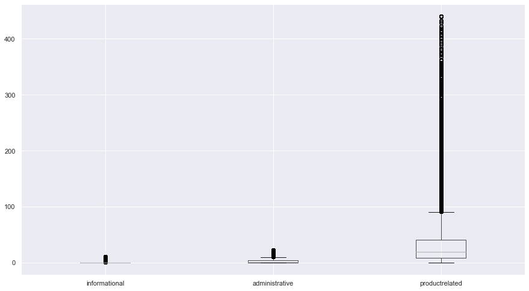

```python
data.boxplot(column=['informational','administrative','productrelated'])
```

### Users have visited product related pages much more times as compared to administrative and informal pages

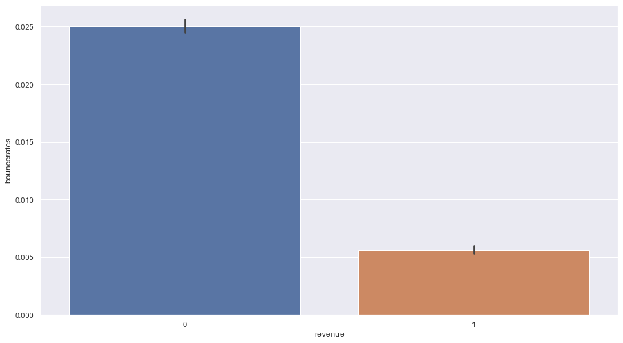

```python
sns.barplot(y='bouncerates',x='revenue',data=data)
```

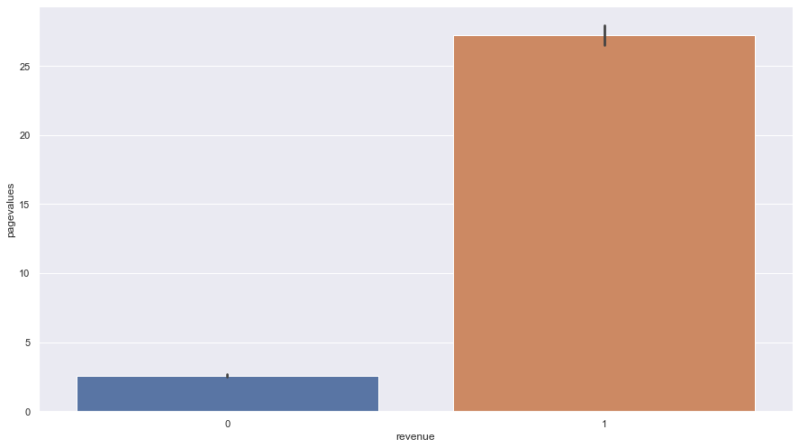

```python
sns.barplot(x='revenue',y='pagevalues',data=data)
```

### higher page values result in higher revenue.

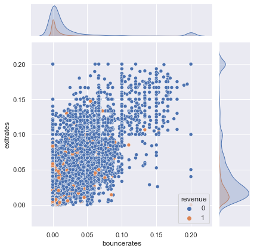

```python
sns.jointplot(data=data, x="bouncerates", y="exitrates", hue="revenue")
```

### Maximum revenue concentration is at lower bounce rate and lower exit rate, which is expected.

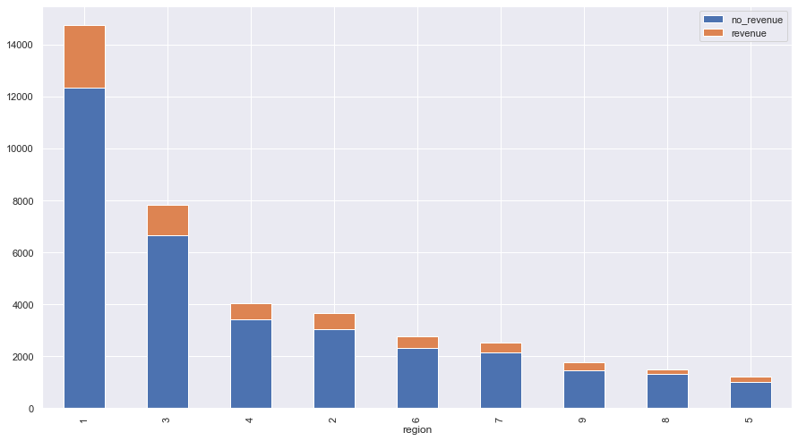

```python
regionwise_revenue=data.groupby(['revenue'])['region'].value_counts()
data2=pd.DataFrame()
data2['no_revenue']=regionwise_revenue[0]
data2['revenue']=regionwise_revenue[1]
data2.plot.bar(stacked=True)
```

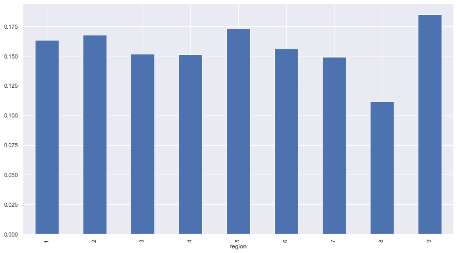

```python
regionwise_revenue_true=regionwise_revenue[1]
regionwise_revenue_false=regionwise_revenue[0]
ratios=regionwise_revenue_true/(regionwise_revenue_false+regionwise_revenue_true)
ratios.plot.bar()
```

### Region 1 has highest number of visitors. but region 9 has highest percentage of successful transactions despite having less number of visitors.

```
[14.28571429 26.18683002 12.5        85.71428571 73.81316998 87.5       ]
```

[figure not shown]

```python
data1=data.groupby('revenue')['visitortype'].value_counts()
data2=pd.DataFrame()
data2['no_revenue']=data1[0]
data2['revenue']=data1[1]
data2['percentage']=data2['revenue']/(data2['revenue']+data2['no_revenue'])
ax=data2[['no_revenue','revenue']].plot.bar(stacked=True,mark_right=True)

kx = -0.2
ky = -0.02
values=np.zeros(6)
count=0
for k in data2.percentage:
    values[count]=k*100
    values[count+3]=(1-k)*100
    count=count+1
print(values)
for i,rec in enumerate(ax.patches):
#     print(i,rec)
    ax.text(rec.get_xy()[0]+rec.get_width()/2+kx,rec.get_xy()[1]+rec.get_height()/2+ky,'{:.2%}'.format(values[i]/100), fontsize=12, color='black')
```

```python
# le=LabelEncoder()
# data['month']=le.fit_transform(data['month'])
# print(le.classes_)
```

```python
# le_visitor=LabelEncoder()
# data['visitortype']=le_visitor.fit_transform(data['visitortype'])
# print(le_visitor.classes_)
```

# Bivariate analysis

```python
# print(le.classes_)
# sns.countplot(y=data.month,hue=data.revenue)
```

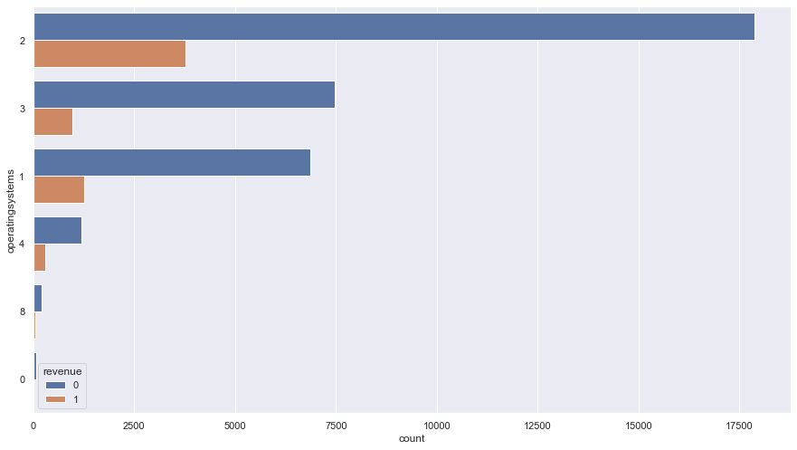

```python
sns.countplot(y=data.operatingsystems,hue=data.revenue)
```

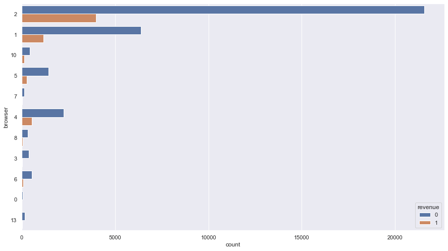

```python
sns.countplot(y=data.browser,hue=data.revenue)
```

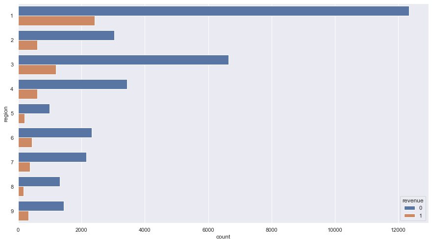

```python
sns.countplot(y=data.region,hue=data.revenue)
```

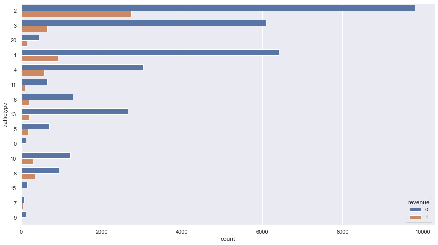

```python
sns.countplot(y=data.traffictype,hue=data.revenue)
```

```python
# print(le_visitor.classes_)
# sns.countplot(y=data.visitortype,hue=data.revenue)
```

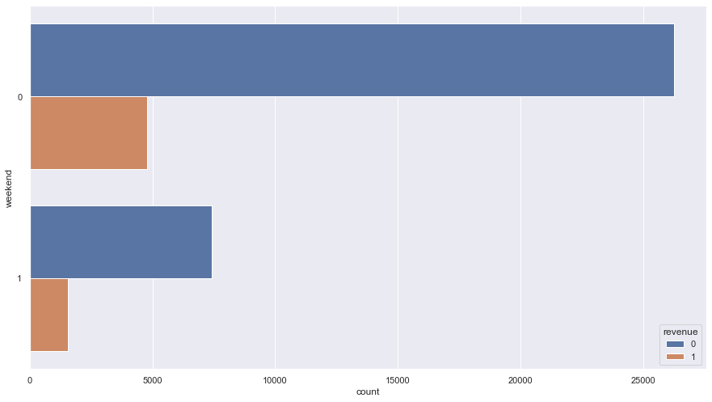

```python
sns.countplot(y=data.weekend,hue=data.revenue)
```

## Inferences from bivariate analysis

1. Month of may has higher visitor count while month of november has the highest sale count.
2. operating system : 2, browser: 2 and region : 1 , traffictype:2 are highest contributor for visitors as well as sale
3. New visitors although lesser in count, has higher percentage of sale where as returning visitors constitute of majority of visits to the site.
4. weekday sale numbers and visitor count are higher compared to weekends

# Outlier analysis

```python
# sns.set(rc={'figure.figsize':(15,8.27)})
# sns.set_theme(style="darkgrid")
# column_names=['administrative','administrative_duration','informational','informational_duration','productrelated','productrelated_duration','bouncerates','pagevalues']
# for col in column_names:

#     col_mean=data[col].mean()
#     col_std=data[col].std()
#     data.drop(data[(data[col]>(col_mean+2*col_std)) | (data[col]<(col_mean-2*col_std))].index,inplace=True)
#     sns.boxplot(data[col])
#     plt.show()
# data.info()
```

```python
data.info()
```

```
<class 'pandas.core.frame.DataFrame'>
RangeIndex: 40000 entries, 0 to 39999
Data columns (total 18 columns):
 #   Column                   Non-Null Count  Dtype
---  ------                   --------------  -----
 0   administrative           39971 non-null  float64
 1   administrative_duration  40000 non-null  float64
 2   informational            39970 non-null  float64
 3   informational_duration   40000 non-null  float64
 4   productrelated           39926 non-null  float64
 5   productrelated_duration  40000 non-null  float64
 6   bouncerates              40000 non-null  float64
 7   exitrates                40000 non-null  float64
 8   pagevalues               40000 non-null  float64
 9   specialday               40000 non-null  float64
 10  month                    40000 non-null  object
 11  operatingsystems         40000 non-null  object
 12  browser                  40000 non-null  object
 13  region                   40000 non-null  int64
 14  traffictype              40000 non-null  object
 15  visitortype              40000 non-null  object
 16  weekend                  40000 non-null  int64
 17  revenue                  40000 non-null  int64
dtypes: float64(10), int64(3), object(5)
memory usage: 5.5+ MB
```

# Model fitting

## 1. Data preparation

```python
# data.drop(columns=['administrative_duration','informational_duration','productrelated_duration','bouncerates'],inplace=True)
# data.drop(columns=['bouncerates'],inplace=True)
data.drop(columns=['exitrates'],inplace=True)
data=pd.get_dummies(data, columns=['operatingsystems','browser','region','month','visitortype'])
print(data.shape)
```

```
(40000, 51)
```

```python
data.info()
```

```
<class 'pandas.core.frame.DataFrame'>
RangeIndex: 40000 entries, 0 to 39999
Data columns (total 51 columns):
 #   Column                         Non-Null Count  Dtype
---  ------                         --------------  -----
 0   administrative                 39971 non-null  float64
 1   administrative_duration        40000 non-null  float64
 2   informational                  39970 non-null  float64
 3   informational_duration         40000 non-null  float64
 4   productrelated                 39926 non-null  float64
 5   productrelated_duration        40000 non-null  float64
 6   bouncerates                    40000 non-null  float64
 7   pagevalues                     40000 non-null  float64
 8   specialday                     40000 non-null  float64
 9   traffictype                    40000 non-null  object
```

[output cut: 43 more lines]

```python
#separate the X_data and y_data
column_names=data.columns

X_data=data.drop(columns=['revenue'])
y_data=data.revenue
print(X_data.shape,y_data.shape)
```

```
(40000, 50) (40000,)
```

```python
data.isna().sum()
```

```
administrative                   29
administrative_duration           0
informational                    30
informational_duration            0
productrelated                   74
productrelated_duration           0
bouncerates                       0
pagevalues                        0
specialday                        0
traffictype                       0
weekend                           0
revenue                           0
operatingsystems_0                0
operatingsystems_1                0
operatingsystems_2                0
operatingsystems_3                0
operatingsystems_4                0
operatingsystems_8                0
browser_0                         0
browser_1                         0
browser_10                        0
browser_13                        0
browser_2                         0
browser_3                         0
browser_4                         0
browser_5                         0
browser_6                         0
browser_7                         0
browser_8                         0
region_1                          0
region_2                          0
region_3                          0
region_4                          0
region_5                          0
region_6                          0
region_7                          0
region_8                          0
region_9                          0
month_Aug                         0
month_Dec                         0
month_Feb                         0
month_Jul                         0
month_June                        0
month_Mar                         0
month_May                         0
month_Nov                         0
month_Oct                         0
month_Sep                         0
visitortype_New_Visitor           0
visitortype_Other                 0
visitortype_Returning_Visitor     0
dtype: int64
```

```python
# # scale the dataset for better fitting
num_vars = [
    'administrative_duration',
    'informational_duration',
    'productrelated_duration',
    'bouncerates',
    'pagevalues'
    # 'administrative',
    # 'informational',
    # 'productrelated',
]

sc = StandardScaler()
for col in num_vars:
    X_data[col] = sc.fit_transform(X_data[[col]])


# scaler=StandardScaler()
# scaler.fit(X_data)
# X_data_scaled=scaler.transform(X_data)


# scaler.fit(X_data[:,1].reshape(-1,1))
# X_data[:,1]=scaler.transform(X_data[:,1].reshape(-1,1))
# admin_duration=X_data[:,1]
# scaler.fit(admin_duration.reshape(-1,1))
# admin_duration_1=scaler.transform(admin_duration.reshape(-1,1))
# admin_duration_1.shape
# X_data[:,1]=admin_duration_1[:,0]
# informational_duration=X_data[:,3]
# scaler.fit(informational_duration.reshape(-1,1))
# informational_duration_1=scaler.transform(informational_duration.reshape(-1,1))

# X_data[:,3]=informational_duration_1[:,0]
# admin_duration=X_data[:,5]
# scaler.fit(admin_duration.reshape(-1,1))
# admin_duration_1=scaler.transform(admin_duration.reshape(-1,1))
# admin_duration_1.shape
# X_data[:,5]=admin_duration_1[:,0]
```

```python
# kNN imputation
from sklearn.impute import KNNImputer
imputer=KNNImputer()
imputer.fit(X_data)
X_data=imputer.transform(X_data)
X_data_scaled=X_data.copy()
```

```python
# train test split
X_train,X_test,y_train,y_test=train_test_split(X_data_scaled,y_data,stratify=y_data,test_size=0.2)
print(X_train.shape,X_test.shape)
```

```
(32000, 50) (8000, 50)
```

```python
y_test.value_counts(normalize=True)
```

```
0    0.84175
1    0.15825
Name: revenue, dtype: float64
```

```python
log_reg=LogisticRegression()
log_reg.fit(X_train,y_train)
```

```
LogisticRegression()
```

```
0.875875
0.483619344773791
[[6542  801]
 [ 192  465]]
```

```
<sklearn.metrics._plot.confusion_matrix.ConfusionMatrixDisplay at 0x7fd4535bfdf0>
```

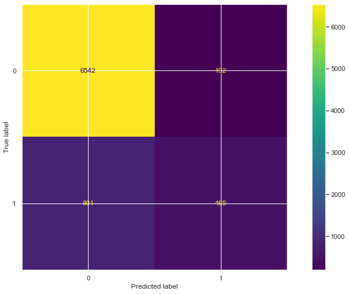

```python
#predict the data and find accuracy
y_pred=log_reg.predict(X_test)
print(metrics.accuracy_score(y_pred,y_test))
print(metrics.f1_score(y_pred,y_test))
print(metrics.confusion_matrix(y_pred,y_test))
metrics.plot_confusion_matrix(log_reg,X_test,y_test)
```

```python
# log_reg_cv=LogisticRegressionCV(cv=10,random_state=0,solver='sag')
# log_reg_cv.fit(X_train,y_train)
```

```python
#predict the data and find accuracy
y_pred=log_reg.predict(X_test)
print(metrics.accuracy_score(y_pred,y_test))
print(metrics.f1_score(y_pred,y_test))
```

```
0.875875
0.483619344773791
```

## Fitting a decision tree classifier

```python
decision_tree=DecisionTreeClassifier(max_depth=6)
```

```python
decision_tree.fit(X_train,y_train)
```

```
DecisionTreeClassifier(max_depth=6)
```

```
0.894875
0.6491447642886942
[[6381  488]
 [ 353  778]]
```

```
<sklearn.metrics._plot.confusion_matrix.ConfusionMatrixDisplay at 0x7fd472bbe7c0>
```

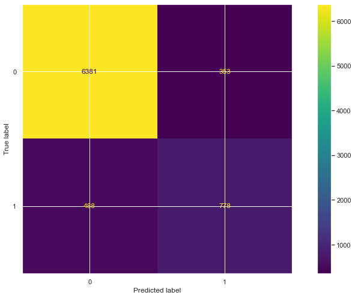

```python
#predict the data and find accuracy
y_pred=decision_tree.predict(X_test)
print(metrics.accuracy_score(y_pred,y_test))
print(metrics.f1_score(y_pred,y_test))
print(metrics.confusion_matrix(y_pred,y_test))
metrics.plot_confusion_matrix(decision_tree,X_test,y_test)
```

### Using grid search CV

```python
parameters={'max_depth':[5,6,7,8,9,10]}
tree_clf=DecisionTreeClassifier(criterion='gini')
tree_cv=GridSearchCV(tree_clf,parameters,scoring='roc_auc')
tree_cv.fit(X_train,y_train)
```

```
GridSearchCV(estimator=DecisionTreeClassifier(),
             param_grid={'max_depth': [5, 6, 7, 8, 9, 10]}, scoring='roc_auc')
```

```
0.894875
0.6491447642886942
[[6381  488]
 [ 353  778]]
DecisionTreeClassifier(max_depth=6)
```

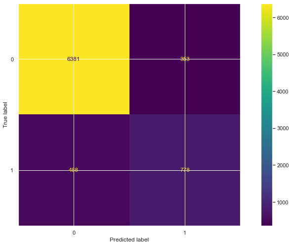

```python
#predict the data and find accuracy
y_pred=tree_cv.predict(X_test)
print(metrics.accuracy_score(y_pred,y_test))
print(metrics.f1_score(y_pred,y_test))
print(metrics.confusion_matrix(y_pred,y_test))
metrics.plot_confusion_matrix(tree_cv,X_test,y_test)
print(tree_cv.best_estimator_)
```

## SVM implementation

```python
# parameters = {'kernel':('linear', 'rbf'), 'C':[1, 10]}
# svc=SVC()
# # clf=GridSearchCV(svc,parameters)
# clf=SVC()
# clf.fit(X_train,y_train)
# #predict the data and find accuracy
# y_pred=clf.predict(X_test)
# print(metrics.accuracy_score(y_pred,y_test))
# print(metrics.f1_score(y_pred,y_test))
# print(metrics.confusion_matrix(y_pred,y_test))
# metrics.plot_confusion_matrix(clf,X_test,y_test)
```

## Prediction on test dataset

```python
#!wget https://raw.githubusercontent.com/saumya221/image_viewer_pyqt5/main/ecommerce_test.csv
```

```python
test_data=pd.read_csv("ecommerce_test.csv")
```

```python
test_data.info()
```

```
<class 'pandas.core.frame.DataFrame'>
RangeIndex: 10000 entries, 0 to 9999
Data columns (total 18 columns):
 #   Column                   Non-Null Count  Dtype
---  ------                   --------------  -----
 0   session_id               10000 non-null  int64
 1   administrative           10000 non-null  int64
 2   administrative_duration  10000 non-null  float64
 3   informational            10000 non-null  int64
 4   informational_duration   10000 non-null  float64
 5   productrelated           10000 non-null  int64
 6   productrelated_duration  10000 non-null  float64
 7   bouncerates              10000 non-null  float64
 8   exitrates                10000 non-null  float64
 9   pagevalues               10000 non-null  float64
 10  specialday               10000 non-null  float64
 11  month                    10000 non-null  object
 12  operatingsystems         10000 non-null  object
 13  browser                  10000 non-null  object
 14  region                   10000 non-null  int64
 15  traffictype              10000 non-null  object
 16  visitortype              10000 non-null  object
 17  weekend                  10000 non-null  bool
dtypes: bool(1), float64(7), int64(5), object(5)
memory usage: 1.3+ MB
```

```python
session_ids=test_data.session_id
test_data.drop('session_id',axis=1,inplace=True)
```

```python
test_data['operatingsystems']=test_data['operatingsystems'].replace('*','0')
test_data['browser']=test_data['browser'].replace('*','0')
test_data['traffictype']=test_data['traffictype'].replace('*','0')
```

```python
test_data.loc[(test_data['informational']==0) & (test_data['informational_duration']>0),'informational']=np.nan

test_data.loc[(test_data['administrative']==0) & (test_data['administrative_duration']>0),'administrative']=np.nan

test_data.loc[(test_data['productrelated']==0) & (test_data['productrelated_duration']>0),'productrelated']=np.nan

test_data.info()
```

```
<class 'pandas.core.frame.DataFrame'>
RangeIndex: 10000 entries, 0 to 9999
Data columns (total 17 columns):
 #   Column                   Non-Null Count  Dtype
---  ------                   --------------  -----
 0   administrative           9994 non-null   float64
 1   administrative_duration  10000 non-null  float64
 2   informational            9995 non-null   float64
 3   informational_duration   10000 non-null  float64
 4   productrelated           9974 non-null   float64
 5   productrelated_duration  10000 non-null  float64
 6   bouncerates              10000 non-null  float64
 7   exitrates                10000 non-null  float64
 8   pagevalues               10000 non-null  float64
 9   specialday               10000 non-null  float64
 10  month                    10000 non-null  object
 11  operatingsystems         10000 non-null  object
 12  browser                  10000 non-null  object
 13  region                   10000 non-null  int64
 14  traffictype              10000 non-null  object
 15  visitortype              10000 non-null  object
 16  weekend                  10000 non-null  bool
dtypes: bool(1), float64(10), int64(1), object(5)
memory usage: 1.2+ MB
```

```python
test_data.drop(columns=['exitrates'],inplace=True)
test_data=pd.get_dummies(test_data, columns=['operatingsystems','browser','region','month','visitortype'])
test_data.shape
```

```
(10000, 50)
```

```python
# # scale the dataset for better fitting
# scaler=StandardScaler()
# scaler.fit(test_data)
# test_data_scaled=scaler.transform(test_data)
num_vars = [
    'administrative_duration',
    'informational_duration',
    'productrelated_duration',
    'bouncerates',
    'pagevalues'
    # 'administrative',
    # 'informational',
    # 'productrelated',
]

sc = StandardScaler()
for col in num_vars:
    test_data[col] = sc.fit_transform(test_data[[col]])
```

```python
# kNN imputation
test_data_scaled=test_data.copy()
imputer=KNNImputer()
imputer.fit(test_data_scaled)
test_data_scaled=imputer.transform(test_data_scaled)
```

## Use the decision tree obtained from grid search and predict the data

```python
y_pred=tree_cv.predict(test_data_scaled)
print(y_pred)
final_output=pd.DataFrame()
final_output["session_id"]=session_ids
final_output["revenue"]=y_pred
final_output.revenue.value_counts(normalize=True)
```

```
[0 0 0 ... 0 0 0]
```

```
0    0.89
1    0.11
Name: revenue, dtype: float64
```

```python
# y_pred=clf.predict(test_data_scaled)
# print(y_pred)
# final_output=pd.DataFrame()
# final_output["session_id"]=session_ids
# final_output["revenue"]=y_pred
# final_output.revenue.value_counts(normalize=True)
```

```python
y_pred=log_reg.predict(test_data_scaled)
print(y_pred)
final_output=pd.DataFrame()
final_output["session_id"]=session_ids
final_output["revenue"]=y_pred
final_output.revenue.value_counts(normalize=True)
```

```
[0 0 0 ... 0 0 0]
```

```
0    0.9155
1    0.0845
Name: revenue, dtype: float64
```

```python
y_pred=decision_tree.predict(test_data_scaled)
print(y_pred)
final_output=pd.DataFrame()
final_output["session_id"]=session_ids
final_output["revenue"]=y_pred
final_output.revenue.value_counts(normalize=True)
```

```
[0 0 0 ... 0 0 0]
```

```
0    0.8898
1    0.1102
Name: revenue, dtype: float64
```

```python
final_output.to_csv("submission_latest_mark2.csv",index=False)
```